# Using Random Forest in R for Butterfly Fauna Distribution in Pakistan

## 2.3 Data Preparation

We now have a set of predictor variables (rasters) and presence points.  
The next step involves extracting every value of every predictor file at the locations of the butterfly presence points.

Why do we do this? To know which climatic conditions the butterflies like and don’t like. With this information we generate a training and a testing set for the Random Forest model.

In particular this means we

```r
#1 deleting unnecessary rows
butterflies <- butterflies[,-(3:5)] #-(3:5) = delete Position 3 to 5

#2 presence-points
presence <- extract(predictors, butterflies) # Extracting presence values from rasters

#3 setting random seed to always create the same random set of points for this example
set.seed(0)
background <- randomPoints(predictors, 400) # creating 400 random absence-points
absence <- extract(predictors, background) # Extracting absence values from rasters

#4 combining presence and absence with value 1 (present) and value 0 (absent)
pb <- c(rep(1, nrow(presence)), rep(0, nrow(absence)))
sdmdata <- data.frame(cbind(pb, rbind(presence, absence))) # putting pb and climate data into a single dataframe

#5 pb as factor
sdmdata[,'pb'] = as.factor(sdmdata[,'pb']) # set column 'pb' as factor, otherwise it'll do Regression

#6 splitting data in training and testing sets
set.seed(123) # set seed so that same sample can be reproduced in future
sample <- sample.int(n = nrow(sdmdata), size = floor(.60*nrow(sdmdata)), replace = F) # selecting 60% of data as sample
train <- sdmdata[sample, ] # filling train set with 60% of original data
test  <- sdmdata[-sample, ] # filling test set with 40% of original data
```

```r
summary(sdmdata)
##  pb            prec             srad          temp_avg          temp_max
##  0: 400   Min.   :  1.00   Min.   : 5652   Min.   :-35.300   Min.   :-35.000
##  1:5870   1st Qu.: 20.00   1st Qu.: 6894   1st Qu.:-11.900   1st Qu.: -6.700
##           Median : 38.00   Median : 8044   Median :  3.000   Median :  9.500
##           Mean   : 39.83   Mean   : 8733   Mean   : -1.043   Mean   :  4.956
##           3rd Qu.: 57.00   3rd Qu.: 9880   3rd Qu.:  8.400   3rd Qu.: 15.800
##           Max.   :108.00   Max.   :16268   Max.   : 19.200   Max.   : 26.200
##           NA's   :134      NA's   :134     NA's   :134       NA's   :134
##     temp_min            vapr             wind
##  Min.   :-36.300   Min.   :0.0000   Min.   :0.400
##  1st Qu.:-16.900   1st Qu.:0.1200   1st Qu.:1.100
##  Median : -3.600   Median :0.3900   Median :1.300
##  Mean   : -7.042   Mean   :0.4149   Mean   :1.464
##  3rd Qu.:  1.400   3rd Qu.:0.6600   3rd Qu.:1.700
##  Max.   : 15.600   Max.   :1.2600   Max.   :6.400
##  NA's   :134       NA's   :134      NA's   :134
```

## 2.4 Generating Random Forest

First we take a look at the structure of this method and check out some important arguments:

**randomForest(argument1, argument2, argumentx)** is the name of the method and implements Breiman’s random forest algorithm based on Breiman and Cutler’s original Fortran code.

*A list of all possible arguments can be found in this dokumentation from [CRAN R Project](https://cran.r-project.org/web/packages/randomForest/randomForest.pdf).*

[output not shown]

Finally we implement the Forest:

```r
#library(randomForest)
set.seed(123)
myForest<- randomForest(pb ~., data=train, importance=TRUE, mtry=3, ntree=200, replace=TRUE, do.trace=TRUE, keep.forest=TRUE, na.action=na.roughfix)
```

```r
myForest
```

```
##
## Call:
##  randomForest(formula = pb ~ ., data = train, importance = TRUE,      mtry = 3, ntree = 200, replace = TRUE, do.trace = TRUE, keep.forest = TRUE,      na.action = na.roughfix)
##                Type of random forest: classification
##                      Number of trees: 200
## No. of variables tried at each split: 3
##
##         OOB estimate of  error rate: 3.48%
## Confusion matrix:
##     0    1 class.error
## 0 124   97 0.438914027
## 1  34 3507 0.009601807
```

**set.seed(123)**: A seed is used to initialize a pseudorandom number generator. If the same seed is deliberately shared, it becomes a key, so two or more systems using matching seeds can generate the same pseudorandom numbers in their own models to reproduce and match the results.

**myForest <-** is the name of the variable in which the forest is stored.

If we want to take a deeper look into one single tree we can use the function **getTree**. This function extracts the structure of a tree from a randomForest object represented as matrix. *myForest* is a randomForest object, *k* is a specific tree to extract and *labelVar=TRUE* means label names are used for splitting variables and predicted classes instead of meaningless numbers.

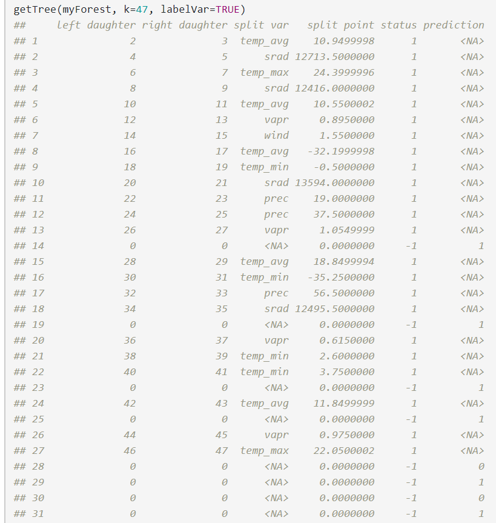

```r
getTree(myForest, k=47, labelVar=TRUE)
```

Img. 3: Screenshot of the function getTree().

What does this mean?

In column 1 row 1 the root of tree k asks, if **split var** is smaller than **split point**. Split var refers to the predictor files and split point to its values. The status delivers the answer in a Boolean expression of true (1) or false (-1).

- Status 1 forwards to a numbered node (column 1) shown in the left and right daughter expanding the tree. Each node queries a different split variable. The prediction column remains as long as the answer is TRUE.
- Status -1 terminates the node resulting in a prediction 1 or 0. The value is taken from the factor pb. This means a butterfly is present or absent.

### 2.4.1 OOB-Error Rate

The out-of-bag (OOB) score is a way of validating the Random Forest model. The original training data is randomly sampled-with-replacement generating small subsets of data. These subsets are also known as bootstrap samples. These samples are then fed as training data. Each of these decision trees is trained separately on these. The concluding result is determined by counting a majority vote from all the decision trees.

The sample that is “left out” in the original data is known as Out-of-Bag sample. This will not be used as training data. After the decision tree model has been trained, this leftover sample (or the OOB) will be given as unseen data to the decision trees. Then the tree will predict the outcome. It compares the OOB outcome with the real outcome in the dataset. If the outcomes are identical, a correct prediction was made. If they are not identical, a false prediction was made.

Long story short: The OOB score is computed as the number of correctly predicted outcomes from the out-of-bag sample.

Therefore the OOB error rate is a good estimate for the generalization error.

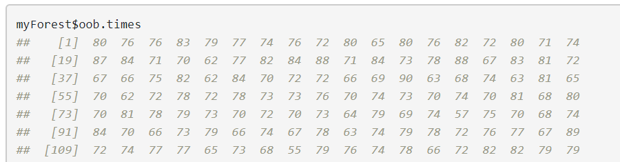

```r
myForest$oob.times
mean(myForest$oob.times)
```

Img. 4: Screenshot of a Matrix showing the times a sample was not used (OOB).

Display of OOB error rate in a matrix. In the last row we can find the final OOB. This is the percentage for wrong or right prediction of presence | absence points.

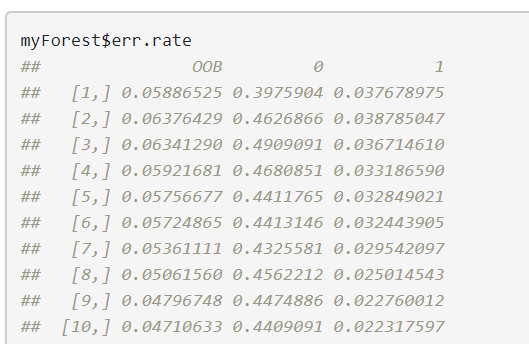

```r
myForest$err.rate
```

Img. 5: Screenshot of the OOB Error Rate.

This plot shows the evolution of the OOB over an increasing number of trees. Why is it important? Because you should ask yourself: “How many trees should I create within a forest?” Answer: There are large fluctuations with a low number of trees and leveling out with a higher number. On x axis the trees are shown, on y axis is the OOB error displayed.

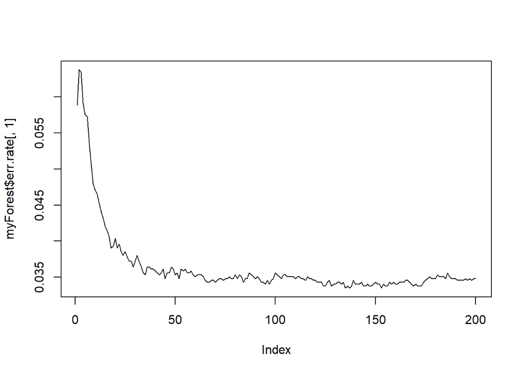

```r
plot(myForest$err.rate[,1], type="l")
```

## 2.5 Prediction

With the information of presence points the first prediction verifies our model.

1. Feed the Forest with training data and calculate the reinstatement error.

```r
class_train <- train$pb
```

The command ‘predict’ initiates the prediction. The previously generated forest (myForest) is used with the dataset ‘train’ again to verify the generated results. There should be a high matching quote and have the smallest possible reinstatement errors on the sample.

With the information of presence points the first prediction verifies our model. The command ‘predict’ initiates the prediction. The previously generated forest (myForest) is used with the dataset ‘train’ again to verify the generated results. There should be a high matching quote and the smallest possible reinstatement errors on the sample.

```r
prediction_train <- predict(myForest, newdata=train)

table_train <- table(class_train, prediction_train) # saving matrix in a table
table_train # perfect results?
```

```
##            prediction_train
## class_train    0    1
##           0  218    3
##           1    0 3464
```

2. Feed the Forest with test data and calculate the generalization error.

```r
class_test <- test$pb

prediction_test <- predict(myForest, newdata=test)

table_test <- table(class_test, prediction_test)
table_test # perfect results?
```

```
##           prediction_test
## class_test    0    1
##          0  100   79
##          1   26 2246
```

### 2.5.1 Plot the Prediction

And finally we are visualizing the prediction

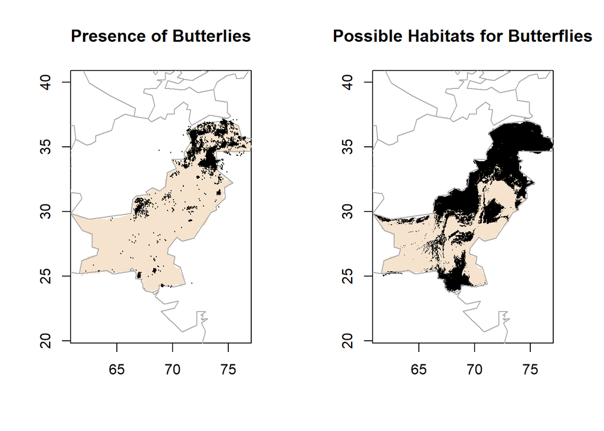

```r
r = raster(predictors, 1)
par(mfrow=c(1,2))
plot(!is.na(r), col=c('white', '#F6E3CE'),legend=FALSE, main='Presence of Butterlies')
plot(wrld_simpl, add=TRUE, border='dark grey')
points(butterflies, pch=19, cex=0.1, col='black')
prediction <- predict(predictors, myForest)

plot(prediction, col=c('#F6E3CE', 'black'), legend=FALSE, main='Possible Habitats for Butterflies')
plot(wrld_simpl, add=TRUE, border='dark grey')
```

### 2.5.2 Variable Importance Plot

The variable importance plot shows the importance for every variable in two methods: Mean Decrease Accuracy and Mean Decrease Gini. More information regarding these two see [Louppe et. al (2013):](https://papers.nips.cc/paper/4928-understanding-variable-importances-in-forests-of-randomized-trees.pdf). The importance increases from bottom to top.

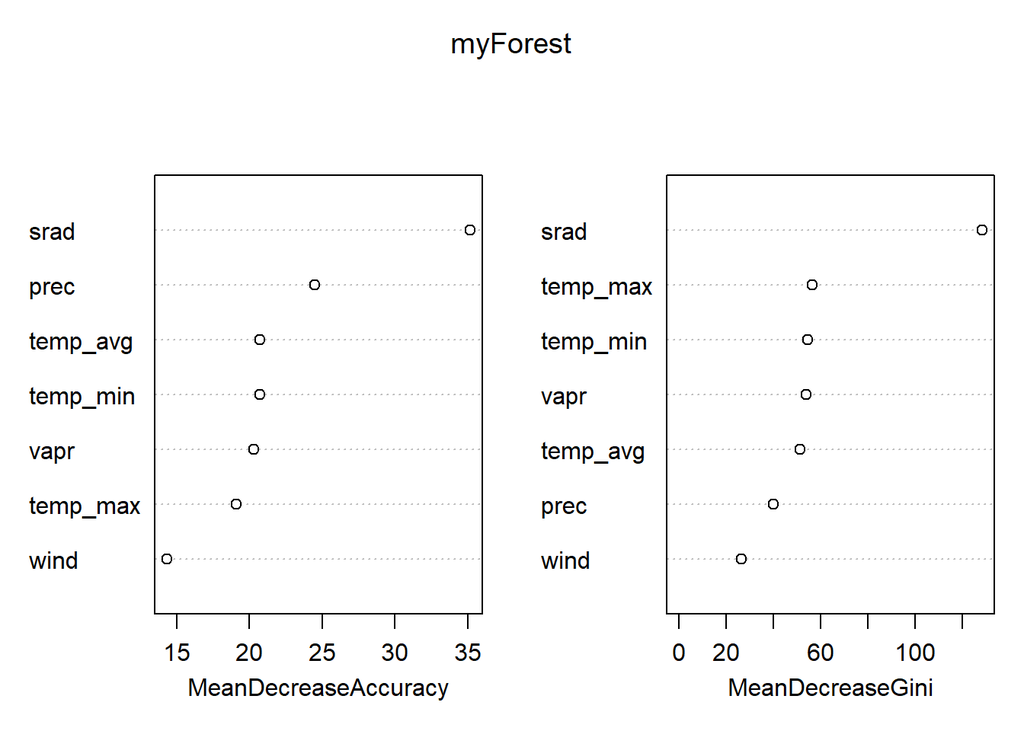

```r
imp <- varImpPlot(myForest)
```

```r
imp
```

```
##          MeanDecreaseAccuracy MeanDecreaseGini
## prec                 24.51009         39.91361
## srad                 35.16589        128.51165
## temp_avg             20.72377         51.29401
## temp_max             19.11231         56.55813
## temp_min             20.70866         54.48442
## vapr                 20.29234         53.75408
## wind                 14.33831         26.55238
```

We can also display how often which variable was used

```r
varUsed(myForest, by.tree=FALSE, count=TRUE)
```

```
## [1] 4164 5447 3641 4119 4229 3594 2752
```

```r
head(sdmdata) #show variables names again
```

```
##   pb prec srad temp_avg temp_max temp_min vapr wind
## 1  1   40 6820    -10.9     -6.2    -15.7 0.10  1.6
## 2  1   49 8292      3.5      9.9     -3.0 0.39  1.4
## 3  1   66 8233      6.3     13.2     -0.5 0.52  1.1
## 4  1   66 9008      7.3     13.4      1.1 0.62  1.1
## 5  1   75 8484      5.8     11.9     -0.2 0.50  1.2
## 6  1   75 8162      4.3     10.2     -1.6 0.47  1.1
```

# 3 Info Dataset

*Why did we choose those variables?*

Img. 6: Butterfly at Malakand, Pakistan.

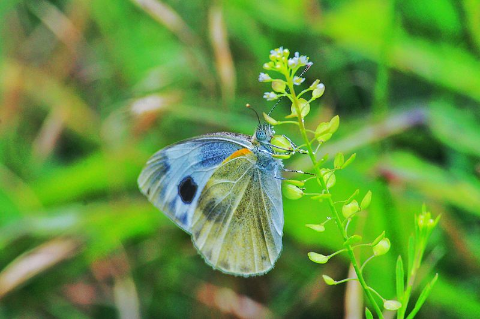

**Solar Radiation (srad):** The bodies of butterflies have to be warm (about 25 to 26 °C) to fly. Because they cannot regulate their body temperature themselves, they depend on their environment, more specifically the sunlight. To get the maximum exposure to warmth they bask in the sun with spreaded wings. But in hotter climates they can also easily overheat so they are usually only active in the early morning, late afternoon or early evening (aka the cooler parts of the day). They rest in the shade during the heat of the day. Butterflies living in cooler climates and moths may warm their bodies by vibrating their wings, and heat insulating hair.

**Precipitation/Water Vapor (prec/vapr):** As the [Scientific American](https://www.scientificamerican.com/article/what-do-butterflies-do-wh/) stated, butterflies are rarely seen during heavy rains and wind. Not only is rain a direct threat of injury or death, but the cool air associated with storms may also reduce temperatures below the thermal threshold for flying. Overcast skies limit their ability to gather the solar radiation needed to fly. When skies darken, butterflies seek shelter in their nighttime homes. Furthermore, a butterfly knocked out of the air by raindrops faces the double threat of crashing in an inhospitable habitat where predators lay in wait, and being unable to warm its body sufficiently to regain flight.

**Wind speed:** As [Professor Robert Dudley](https://www.mentalfloss.com/article/56464/how-can-butterfly-weighing-no-more-feather-fly-wind), head of the Animal Flight Laboratory at U.C. Berkeley states, no matter the animal, if wind speed exceeds maximum flight speed, then it can’t fly. Different species of butterflies fly at different speeds, and the range is about 1.5 to 10 meters per second. If the windspeed is any higher than that, then the butterfly isn’t slipping the surly bounds of Earth to cut through it. He also says that many small butterflies avoid high winds as they would merely drift. A butterfly’s wing is more suceptible to ambient winds, so, while capable of flying into the wind, they aren’t exactly engineered for it. Nevertheless, windy days can also be useful. With help of tailwinds, migrating butterflies can travel at 100km/h at an altitude of several hundred metres.

**Temperature (min/max/avg):** As stated butterflies need warm temperatures to maintain their body warmth. It also affects the metamorphosis. Larva and pupae exposed to warmer temperatures develope into butterflies about twice as fast as those exposed to cooler temperatures. Therefore the temperature is an important variable.

We took the predictor files from [WorldClim](http://worldclim.org/version2). It has average monthly climate data for minimum, mean, and maximum temperature and for precipitation for the years of 1970 to 2000. Variables can downloaded for different spatial resolutions, from 30 seconds (~1 km²) to 10 minutes (~340 km²). Each download is a “zip” file containing 12 GeoTiff (.tif) files, one for each month of the year (January is 1; December is 12).

Below the units of each predictor is shown:

| Name of predictor file | Description |
| --- | --- |
| temp_min | minimum temperature in °C |
| temp_max | maximum temperature in °C |
| temp_avg | average temperature in °C |
| prec | precipitation in mm |
| srad | solar radiation in kJ m<sup>-2</sup> day<sup>-1</sup> |
| vapr | water vapor pressure in kPa |
| wind | wind speed in m s<sup>-1</sup> |

# 4 Sources

- [Random Forests by Leo Breiman and Adele Cutler](https://www.stat.berkeley.edu/~breiman/RandomForests/)
- [CRAN R Package Information for randomForest](https://cran.r-project.org/web/packages/randomForest/randomForest.pdf)
- [Fick, S.E. and R.J. Hijmans, 2017. Worldclim 2: New 1-km spatial resolution climate surfaces for global land areas. International Journal of Climatology](http://worldclim.org/version2)
- [Olson, D. M., Dinerstein, E., Wikramanayake, E. D., Burgess, N. D., Powell, G. V. N., Underwood, E. C., D’Amico, J. A., Itoua, I., Strand, H. E., Morrison, J. C., Loucks, C. J., Allnutt, T. F., Ricketts, T. H., Kura, Y., Lamoreux, J. F., Wettengel, W. W., Hedao, P., Kassem, K. R. 2001. Terrestrial ecoregions of the world: a new map of life on Earth. Bioscience 51(11):933-938.](https://www.worldwildlife.org/publications/terrestrial-ecoregions-of-the-world)
- Tshikolovets, V.V. & J. Pagès (2016): The butterflies of Pakistan. Pardubice.
- [Louppe, Gilles & Wehenkel, Louis & Sutera, Antonio & Geurts, Pierre. (2013). Understanding variable importances in Forests of randomized trees. Advances in Neural Information Processing Systems. 26.](https://papers.nips.cc/paper/4928-understanding-variable-importances-in-forests-of-randomized-trees)
- What do butterflies do when it rains? by [Scientific American](https://www.scientificamerican.com/article/what-do-butterflies-do-wh/)
- [How Can a Butterfly, Weighing No More Than a Feather, Fly Into the Wind?](https://www.mentalfloss.com/article/56464/how-can-butterfly-weighing-no-more-feather-fly-wind)

**Image sources**

- “Example for a simple everyday decision tree” by [nexttech](https://dev.to/nexttech/classification-and-regression-analysis-with-decision-trees-jgp)
- “Run Forrest, Run!” via [giphy](https://giphy.com/)
- “Butterfly at Malakand, Pakistan” by [Kasim Patel](https://commons.wikimedia.org/wiki/File:Butterfly_at_Malakand,_Pakistan.jpg)

# 5 Further Information

- [Simplilearn: Random Forest Algorithm](https://www.simplilearn.com/random-forest-algorithm-article)
- [Tony Yiu: Understandig Random Forest: How the Algorthm works and why it is so effective](https://towardsdatascience.com/understanding-random-forest-58381e0602d2)

For a quick summary watch this video by [Gopal Prasad Malakar](https://www.youtube.com/channel/UCASIK966SA2NyLh5Ls6-21A):

[video not shown]

# 6 Session info